# Reproducible Research: Peer Assessment 1

### Loading and preprocessing the data :

```r
activity=read.csv(unzip('activity.zip')) # unzip and load the file
```

**Data Structure:**

```r
str(activity) # View data structure
```

```
## 'data.frame':    17568 obs. of  3 variables:
##  $ steps   : int  NA NA NA NA NA NA NA NA NA NA ...
##  $ date    : Factor w/ 61 levels "2012-10-01","2012-10-02",..: 1 1 1 1 1 1 1 1 1 1 ...
##  $ interval: int  0 5 10 15 20 25 30 35 40 45 ...
```

**Data Summary:**

```r
summary(activity) # View data Summary
```

```
##      steps              date          interval
##  Min.   :  0    2012-10-01:  288   Min.   :   0
##  1st Qu.:  0    2012-10-02:  288   1st Qu.: 589
##  Median :  0    2012-10-03:  288   Median :1178
##  Mean   : 37    2012-10-04:  288   Mean   :1178
##  3rd Qu.: 12    2012-10-05:  288   3rd Qu.:1766
##  Max.   :806    2012-10-06:  288   Max.   :2355
##  NA's   :2304   (Other)   :15840
```

### What is mean & median total number of steps taken per day?

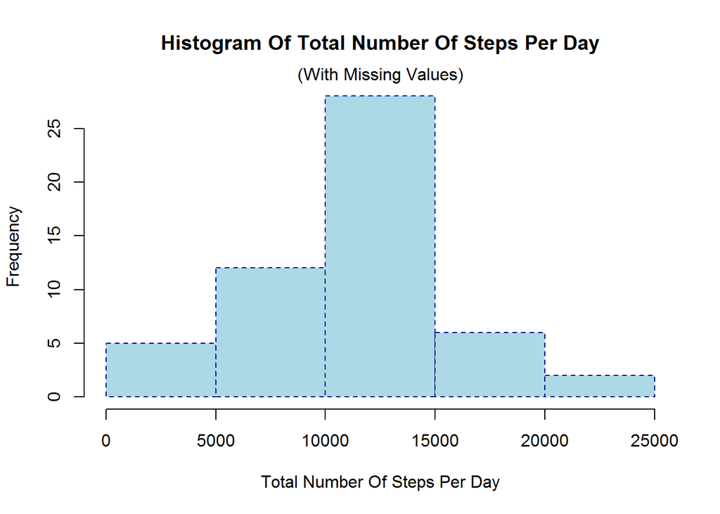

```r
totalstepsperday=aggregate(steps~date,activity,sum) # sum total steps over each day
hist(totalstepsperday$steps,  # Frequency(histogram) of total steps per day
     col="lightblue",
     border="blue4",
     lty=2,
     main="Histogram Of Total Number Of Steps Per Day",
     xlab="Total Number Of Steps Per Day")
mtext("(With Missing Values)")
```

```r
meantotsteps=mean(totalstepsperday$steps) # Average total steps per day
mediantotsteps=median(totalstepsperday$steps)# Median total steps per day
```

**Mean Total Number Of Steps Per Day (with missing values) :** 10766.19

**Median Total Number Of Steps Per Day (with missing values) :** 10765

### What is the average daily activity pattern?

**Generate New Dataframe to track average steps per interval :**

```r
avgstepsperinterval=aggregate(steps~interval,activity,mean) # avg step per interval
str(avgstepsperinterval);summary(avgstepsperinterval)
```

```
## 'data.frame':    288 obs. of  2 variables:
##  $ interval: int  0 5 10 15 20 25 30 35 40 45 ...
##  $ steps   : num  1.717 0.3396 0.1321 0.1509 0.0755 ...
```

```
##     interval        steps
##  Min.   :   0   Min.   :  0
##  1st Qu.: 589   1st Qu.:  2
##  Median :1178   Median : 34
##  Mean   :1178   Mean   : 37
##  3rd Qu.:1766   3rd Qu.: 53
##  Max.   :2355   Max.   :206
```

**Time Series Plot - *Average Steps per 5 min interval Over all Days***

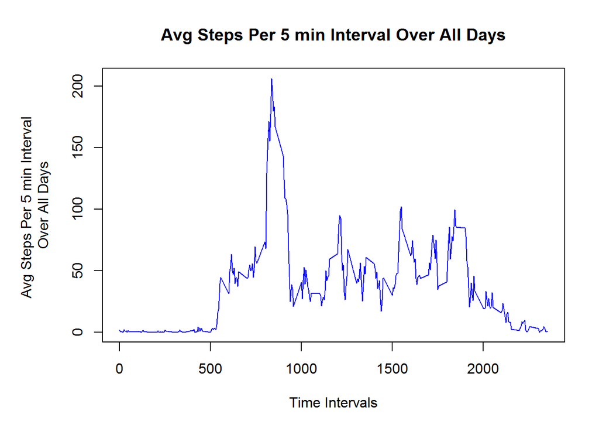

```r
par(mar=c(5,6,4,2))
plot(avgstepsperinterval$interval,
     avgstepsperinterval$steps,
     type="l",
     main="Avg Steps Per 5 min Interval Over All Days",
     xlab="Time Intervals",
     ylab="Avg Steps Per 5 min Interval \nOver All Days",
     col="blue")
```

**Interval with Maximum Average Steps :**

```r
intmaxsteps=avgstepsperinterval$interval[avgstepsperinterval$steps==max(avgstepsperinterval$steps)]
```

*5 min Interval with Maximum Average Steps* : 835

### Imputing missing values

**Number of Missing Values :**

```r
numissingvalues=nrow(activity[is.na(activity$steps),])
```

**Total Number of Missing Values :** 2304

**Filling Missing Values (*use mean of time interval*) :**

```r
activitynew=merge(activity,avgstepsperinterval,by="interval") # merge
summary(activitynew) # Review data frame & NA totals
```

```
##     interval       steps.x             date          steps.y
##  Min.   :   0   Min.   :  0    2012-10-01:  288   Min.   :  0
##  1st Qu.: 589   1st Qu.:  0    2012-10-02:  288   1st Qu.:  2
##  Median :1178   Median :  0    2012-10-03:  288   Median : 34
##  Mean   :1178   Mean   : 37    2012-10-04:  288   Mean   : 37
##  3rd Qu.:1766   3rd Qu.: 12    2012-10-05:  288   3rd Qu.: 53
##  Max.   :2355   Max.   :806    2012-10-06:  288   Max.   :206
##                 NA's   :2304   (Other)   :15840
```

```r
# replace NA's with mean of intervals
activitynew$steps.x[is.na(activitynew$steps.x)]=round(activitynew$steps.y[is.na(activitynew$steps.x)],0)
activitynew=activitynew[,c('interval','steps.x','date')] # Drop the merged column
names(activitynew)[2]='steps' # rename steps.x to steps
summary(activitynew) # re-check values for NA's
```

```
##     interval        steps             date
##  Min.   :   0   Min.   :  0   2012-10-01:  288
##  1st Qu.: 589   1st Qu.:  0   2012-10-02:  288
##  Median :1178   Median :  0   2012-10-03:  288
##  Mean   :1178   Mean   : 37   2012-10-04:  288
##  3rd Qu.:1766   3rd Qu.: 27   2012-10-05:  288
##  Max.   :2355   Max.   :806   2012-10-06:  288
##                               (Other)   :15840
```

** *Note absence of NA’s in the second summary above*

**Histogram, mean and median of total steps taken per day for New Dataframe equal to activity, but with missing values filled :**

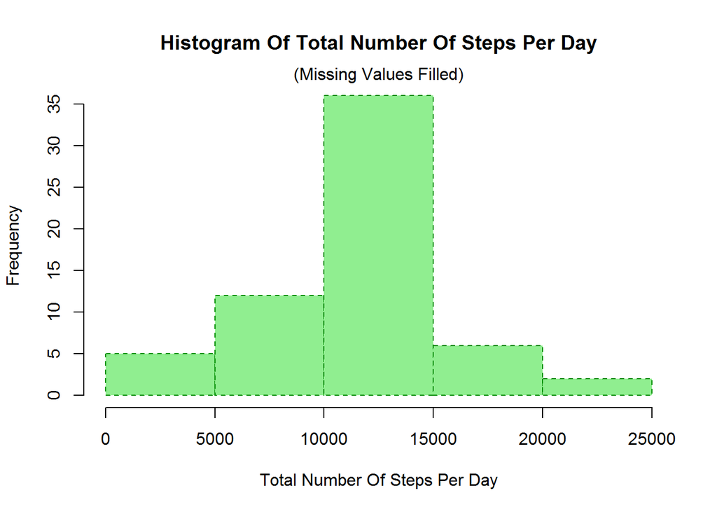

```r
newtotalstepsperday=aggregate(steps~date,activitynew,sum) # sum total steps over each day
hist(newtotalstepsperday$steps,  # Frequency(histogram) of total steps per day
     col="lightgreen",
     border="green4",
     lty=2,
     main="Histogram Of Total Number Of Steps Per Day",
     xlab="Total Number Of Steps Per Day")
mtext("(Missing Values Filled)")
```

```r
newmeantotsteps=mean(newtotalstepsperday$steps) # Average total steps per day
newmediantotsteps=median(newtotalstepsperday$steps)# Median total steps per day
```

**New Mean Total Number Of Steps Per Day (Missing values filled) :** 10765.64

**New Median Total Number Of Steps Per Day (Missing values filled) :** 10762

**Impact Of Adding Missing Values :**

```r
old=c("mean"=meantotsteps,"median"=mediantotsteps)
new=c("mean"=newmeantotsteps,"median"=newmediantotsteps)
oldnew=data.frame(old,new)
oldnew$diff=(new-old)/old*100
oldnew
```

```
##          old   new    diff
## mean   10766 10766 -0.0051
## median 10765 10762 -0.0279
```

**“diff”** column in the above dataframe indicates the % difference in the **mean and median values** from the **earlier** estimates **with missing values** and **current** estimates **with missing values filled in**. As apparent, there is a very marginal, practically negligible difference between the earlier and current estimates. However, it is quite possible that the method used to fill in the missing values may impact the estimates and can be a separate area to evaluate.

### Differences in activity patterns between weekdays and weekends :

**Add a new column to track weekday/weekend :**

```r
# Use activitynew dataframe and add a day column for weekdays/weekends
# Use weekday function to identify weekends
activitynew$day[weekdays(as.Date(activitynew$date))%in%c("Sunday","Saturday")]="weekend"
activitynew$day[is.na(activitynew$day)]="weekday" # All other days are weekdays
activitynew$day=as.factor(activitynew$day) # Convert this column to factor
str(activitynew) # Review structure with added column
```

```
## 'data.frame':    17568 obs. of  4 variables:
##  $ interval: int  0 0 0 0 0 0 0 0 0 0 ...
##  $ steps   : num  2 0 0 0 0 0 0 0 0 0 ...
##  $ date    : Factor w/ 61 levels "2012-10-01","2012-10-02",..: 1 54 28 37 55 46 20 47 38 56 ...
##  $ day     : Factor w/ 2 levels "weekday","weekend": 1 1 2 1 2 1 2 1 1 2 ...
```

```r
newavgstepsinterval=aggregate(steps~interval+day,activitynew,mean) # avg step per interval by type of day
```

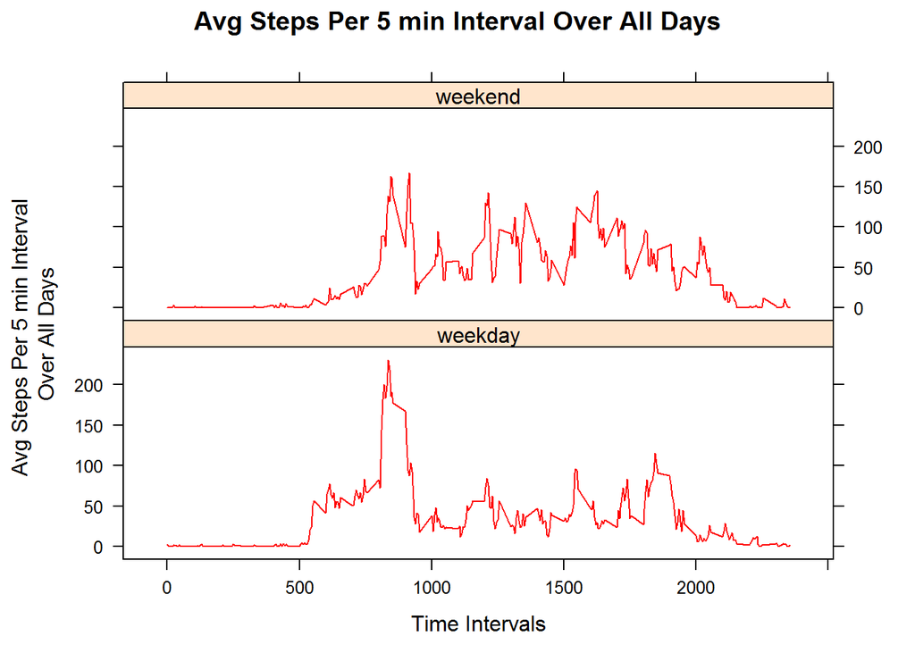

```r
library(lattice)
xyplot(steps~interval|day,
       newavgstepsinterval,
       type="l",
       main="Avg Steps Per 5 min Interval Over All Days",
       xlab="Time Intervals",
       ylab="Avg Steps Per 5 min Interval \nOver All Days",
       col="red",
       layout=c(1,2))
```